# Interpretable Neural Networks for Customer Choice Modelling

In this step we varied from the SHOPPER paper as we did not normalize the price by taking the log and also do not take the negative. We found our model to be able to recognize that a higher price is bad for a product to be bought and it will learn to lower the utility of a product if the price gets higher. We also estimated the price effects of each individual item, whereas the authours of SHOPPER normalize prices within categories. We did this to get the most granular price effects possible. This complex embedding structure allows us to have a price sensitivity for every customer and every product instead of having one estimate for all users.

```python
# Embedding the product (shape will be (None, 1, embedding_size))
item_embedding_price = Embedding(name = 'item_embedding_price',
                          input_dim = item_len,
                          output_dim = embedding_size)(item)

# Embedding the user (shape will be (None, 1, embedding_size))
user_embedding_price = Embedding(name = "user_embedding_price",
                                 input_dim = user_len,
                                 output_dim = embedding_size)(user)

# Merge the layers with a dot product along the second axis
# (shape will be (None, 1, 1))
user_item_price = Dot(name = 'user_item_price_dot', axes = 2)([item_embedding_price, user_embedding_price])

# Reshape to be a single number (shape will be (None, 1))
user_item_price = Reshape(target_shape = (1,))(user_item_price)

# multiply price effect by price to get effect on utility
user_item_price = multiply([price, user_item_price], name = 'user_item_price')
```

Lastly we consider the *Seasonality* $\delta_{wt}^T \mu_{c}$ which we calculate from a new set of item embeddings $\mu_{c}$ and a set of week embedddings $\delta_{w}$. From these latent vectors we again take the dot product to calculate the *Seasonality*.

```python
# Embedding the week (shape will be (None, 1, embedding_size))
week_embedding = Embedding(name = 'week_embedding',
                               input_dim = week_len,
                               output_dim = embedding_size)(week)

# Embedding the product (shape will be (None, 1, embedding_size))
week_item_embedding = Embedding(name = 'week_item_embedding',
                           input_dim = item_len,
                           output_dim = embedding_size)(item)


# Merge the layers with a dot product along the second axis
# (shape will be (None, 1, 1))
week_item = Dot(name = 'week_item', axes = 2)([week_item_embedding, week_embedding])

# Reshape to be a single number (shape will be (None, 1))
week_item = Reshape(target_shape = (1, ))(week_item)
```

```python
# Sum up various dot products to get total utility value
x = keras.layers.add([item_pop, user_item, user_item_price, week_item, item_basket])

# Squash outputs for classification
out = Dense(1, activation = 'sigmoid', name = 'output')(x)

# Define model
model = Model(inputs = [user, item, price, week, basket], outputs = out)

# Compile using specified optimizer and loss
model.compile(optimizer = Adam(lr=0.0002), loss = 'binary_crossentropy',
              metrics = ['accuracy'])
```

```python
print(model.summary())
```

```
Model: "model_3"
__________________________________________________________________________________________________
Layer (type)                    Output Shape         Param #     Connected to
==================================================================================================
item (InputLayer)               (None, 1)            0
__________________________________________________________________________________________________
basket (InputLayer)             (None, None)         0
__________________________________________________________________________________________________
prod_embed_shared_embedding (Em multiple             3590400     item[0][0]
                                                                 basket[0][0]
__________________________________________________________________________________________________
user (InputLayer)               (None, 1)            0
__________________________________________________________________________________________________
item_embedding_price (Embedding (None, 1, 100)       3590400     item[0][0]
__________________________________________________________________________________________________
user_embedding_price (Embedding (None, 1, 100)       497600      user[0][0]
__________________________________________________________________________________________________
week (InputLayer)               (None, 1)            0
__________________________________________________________________________________________________
lambda_3 (Lambda)               (None, 100)          0           prod_embed_shared_embedding[1][0]
__________________________________________________________________________________________________
user_embedding (Embedding)      (None, 1, 100)       497600      user[0][0]
__________________________________________________________________________________________________
user_item_price_dot (Dot)       (None, 1, 1)         0           item_embedding_price[0][0]
                                                                 user_embedding_price[0][0]
__________________________________________________________________________________________________
week_item_embedding (Embedding) (None, 1, 100)       3590400     item[0][0]
__________________________________________________________________________________________________
week_embedding (Embedding)      (None, 1, 100)       5400        week[0][0]
__________________________________________________________________________________________________
item_item_embedding (Embedding) (None, 1, 100)       3590400     item[0][0]
__________________________________________________________________________________________________
reshape_15 (Reshape)            (None, 1, 100)       0           lambda_3[0][0]
__________________________________________________________________________________________________
item_pop (Embedding)            (None, 1, 1)         35904       item[0][0]
__________________________________________________________________________________________________
user_item (Dot)                 (None, 1, 1)         0           prod_embed_shared_embedding[0][0]
                                                                 user_embedding[0][0]
__________________________________________________________________________________________________
price (InputLayer)              (None, 1)            0
```

[output cut: 18 more lines]

```
reshape_16 (Reshape)            (None, 1)            0           item_basket[0][0]
__________________________________________________________________________________________________
add_3 (Add)                     (None, 1)            0           reshape_13[0][0]
                                                                 reshape_14[0][0]
                                                                 user_item_price[0][0]
                                                                 reshape_18[0][0]
                                                                 reshape_16[0][0]
__________________________________________________________________________________________________
output (Dense)                  (None, 1)            2           add_3[0][0]
==================================================================================================
Total params: 15,398,106
Trainable params: 15,398,106
Non-trainable params: 0
__________________________________________________________________________________________________
None
```

Putting all of the above steps together leads to the model summary that can be seen in the code above. The graphic below illustrates how the embeddings are interconnected. There the different embeddings, input layers etc. have different shapes to tell them apart and the individual components of SHOPPER equation 1 and 2 are colorcoded so that it gets easier to track what part goes where.

[figure not shown]

*Our model architecture*

Like already mentioned when creating the item-price embedding, in this step we varied from the SHOPPER paper as we did not normalize the price by taking the log and also do not take the negative. Therefore we can just add up all the components in our last layer and calculate the utility this way.

[figure not shown]

*Comparison between our model and SHOPPER*

```python
story = model.fit({'user': X_train['encoded_user'], 'item': X_train['encoded_prods'], 'price':X_train['price'], 'week': X_train['encoded_week'],
                   'basket': basket_prods_train_pad},
          {'output': Y_train},
          epochs=3, verbose=1, validation_split = 0.1, batch_size = 128)
```

```
Train on 8299710 samples, validate on 922191 samples
```

```python
story.history
```

```
{'acc': [0.7654360212583874, 0.8658132633551283, 0.9100660143545317],
 'loss': [0.4747343215478976, 0.311318981209224, 0.22580939695331692],
 'val_acc': [0.8043236162585331, 0.8135375426568232, 0.8130777680548156],
 'val_loss': [0.414175460535463, 0.41584345185668947, 0.45761839554877254]}
```

We train for a small number of epochs with a low learning rate because, during experimentation, we found our model to overfit on the training set very quickly. This is likely because the data is individualized (we are using unique identifiers for users and items), so the model can not inherently generalize well. One option to be discussed in future research could be to see the effect of adding a regularization parameter to the loss function.

```python
# make predictions
preds = model.predict({'user': X_test['encoded_user'], 'item': X_test['encoded_prods'], 'price':X_test['price'],
                       'week':X_test['encoded_week']})
```

```python
X_test.loc[: , 'bought'] = Y_test
X_test.loc[:,'pred_prob'] = preds

# change probabilities to binary classification
# used cutoff of 0.5, because distribution of 1's and 0's is 50-50
X_test['pred'] = round(X_test['pred_prob'])
```

## Results

After training we take a look at our results. First, we see how the model performed on our prediction task by looking at the ROC and the AUC. We use an AUC score of 0.5 as a naive benchmark, to see if our model is at least better than predicting randomly. Recall that the distribution of 1's and 0's is balanced, due to our previous sampling procedure.

```python
# Python script for confusion matrix creation.
from sklearn.metrics import confusion_matrix
from sklearn.metrics import accuracy_score
from sklearn.metrics import classification_report
actual = X_test['bought']
predicted = X_test['pred']
results = confusion_matrix(actual, predicted)
print('Confusion Matrix :')
print(results)
print('Accuracy Score :',accuracy_score(actual, predicted))
print('Report : ')
print(classification_report(actual, predicted))
```

```
Confusion Matrix :
[[920699 226066]
 [204955 953756]]
Accuracy Score : 0.8130446814453934
Report :
              precision    recall  f1-score   support

           0       0.82      0.80      0.81   1146765
           1       0.81      0.82      0.82   1158711

    accuracy                           0.81   2305476
   macro avg       0.81      0.81      0.81   2305476
weighted avg       0.81      0.81      0.81   2305476
```

```python
def compute_roc(y_true, y_pred, plot=False):
    """
    TODO
    :param y_true: ground truth
    :param y_pred: predictions
    :param plot:
    :return:
    """
    fpr, tpr, _ = roc_curve(y_true, y_pred)
    auc_score = auc(fpr, tpr)
    if plot:
        plt.figure(figsize=(7, 6))
        plt.plot(fpr, tpr, color='blue',
                 label='ROC (AUC = %0.4f)' % auc_score)
        plt.legend(loc='lower right')
        plt.title("ROC Curve")
        plt.xlabel("FPR")
        plt.ylabel("TPR")
        plt.show()

    return fpr, tpr, auc_score
```

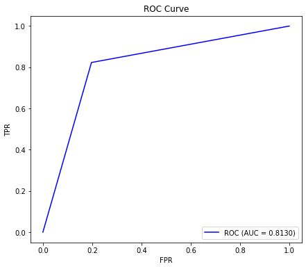

```
(array([0.        , 0.19713368, 1.        ]),
 array([0.       , 0.8231181, 1.       ]),
 0.8129922133759272)
```

```python
from sklearn.metrics import roc_curve, auc
import matplotlib.pyplot as plt

# plot ROC
compute_roc(X_test['bought'], X_test['pred'], plot=True)
```

We can clearly see that the model outperforms random guessing. However, as evident from the ROC, the model can correctly distinguish between purchased and unpurchased items at lower thresholds. But, eventually, the model reaches a plateau and can not improve its predictions. We also observed this in the accuracy measure during model training.

## Embeddings

### Item Embeddings

An additional benefit of this model is the embeddings that it generates. These embeddings can give insights into user preferences, seasonal factors and price elasticities. Below we will take a look at the resulting embeddings. First we define a function to extract our embeddings.

```python
def get_model_embeddings(model_name, layer_name, encoder_name):
  import numpy as np
  import pandas as pd

  embeddings = model_name.get_layer(layer_name)
  embeddings_weights = embeddings.get_weights()[0]

  integer_mapping = {l:i for i, l in enumerate(encoder_name.classes_)}
  embeddings_dict = {w:embeddings_weights[idx] for w, idx in integer_mapping.items()}

  vectors_df = np.array([v for i, v in embeddings_dict.items()])
  names = [i for i, v in embeddings_dict.items()]
  vectors_df = pd.DataFrame(data = vectors_df, index = names)

  return vectors_df
```

Since we have over 91 categories to consider, we will look at a small sample of 6 categories to see how our embeddings look.

```python
# extract item embeddings
item_vectors_df = get_model_embeddings(model, 'prod_embed_shared_embedding', le)

item_vectors_df = item_vectors_df.merge(cat_subcat_text_groups, left_index=True, right_on='article_text')
item_vectors_df = item_vectors_df.set_index(['category_name', 'subcategory_name', 'article_text'])

cats_to_consider = ['condiments', 'oil', 'fresh_pasta', 'milk', 'fruits', 'meat_sausages']
item_vectors_df_subset = item_vectors_df.loc[item_vectors_df.index.get_level_values('category_name').isin(cats_to_consider)]
item_vectors_df_subset = item_vectors_df_subset.sort_index(level = 'category_name')
```

To reduce the number of dimensions, we use a relatively new method of dimensionality reduction called UMAP. UMAP is another dimensionality reduction technique, like T-SNE, but has it's own algorithm. UMAP is much faster and can capture global relationships better (*McInnes et al., 2018*).

```python
import umap

reducer = umap.UMAP(n_neighbors= 2,
                    n_components = 2,
                    min_dist = 0.1,
                    metric = 'cosine')
viz = reducer.fit_transform(item_vectors_df_subset)

item_embeddings_umap = pd.DataFrame(viz, columns=['dim_1', 'dim_2'], index=item_vectors_df_subset.index).reset_index()
```

```python
datasource = ColumnDataSource(item_embeddings_umap)
color_mapping = CategoricalColorMapper(factors= [x for x in item_embeddings_umap['category_name'].unique()],
                                       palette=Accent[6])

plot_figure = figure(
    title='UMAP projection of the Item Embeddings',
    plot_width=800,
    plot_height=800,
    tools=('pan, wheel_zoom, reset')
)

plot_figure.add_tools(HoverTool(tooltips=[("Label1", "@article_text")]))

plot_figure.circle(
    'dim_1',
    'dim_2',
    source=datasource,
    color=dict(field='category_name', transform=color_mapping),
    line_alpha=0.6,
    fill_alpha=0.6,
    size=6
)
show(plot_figure)
```

[interactive chart not shown]

With the help of UMAP we can find clusters of products that where bought by similar customers. A very nice example can be found in the bottom left with several lactose free products. We then can for example conclude that these customers are lactose intolerant and consider it for our marketing efforts.

### Seasonality

Another feature of our model, similar to SHOPPER, is the usage of seasonal effects on shopping preferences. To calculate seasonal effects we take the dot product of our respective item and week embeddings. Below we show the seasonal scores for the week of Easter. The item with the second highest score is an Easter product and we see many more chocolate items with a higher score than other weeks. Our model is able to identify these products that would be in higher demand during Easter, showing that seasonal effects have been picked up by the model.

```python
week_vectors_df = get_model_embeddings(model, 'week_embedding', le_week)
week_item_vectors_df = get_model_embeddings(model, 'week_item_embedding', le)
seasonality = week_vectors_df.dot(week_item_vectors_df.T).T
```

```python
#easter (lots of easter chocolate show up)
seasonality[12].sort_values(ascending = False)[0:10]
```

```
erdbeeren 1kg steige                     0.766977
osterbrot 400g                           0.694283
osterkranz mit rosinen 650g              0.670686
riegelein ostermisch  beutel 225g        0.546345
flensburger frühlingsbock 0.33l mw bv    0.517225
lindt mini goldhase   60% dark 50g       0.512661
lindt mini goldhase  50g                 0.506143
ferrero kinder schokobons xxl 500g       0.484598
lindt alpenmilch mini  eier 100g         0.481230
trinkkokosnuss                           0.477219
Name: 12, dtype: float32
```

Although it may be fairly obvious that chocolate sells more during Easter, this information can still be of value to retailers. With this knowledge retailers can see which specific items are more likely to be bought than others. They can then avoid printing coupons for seasonal items that are near the top of the list, since shoppers will seek them out anyways. Instead retailers can focus on seasonal products that have a lower score, to induce shoppers to purchase them, and reduce in-store waste.

### Price Elasticities

We now consider the price elasticities generated by our model. The goal of generating these is to be able to accurately see the effect price has on the probability of a shopper purchasing a specific item or not. Using this, a retailer could potentially generate personalized coupons that bring the price of an item down to a consumer's maximum willingness to pay. We test this on our model by taking a shopper and an item, hold all other variables constant, and vary only the price of the item.

```python
user_price_vectors_df = get_model_embeddings(model, 'user_embedding_price', le_user)
item_price_vectors_df = get_model_embeddings(model, 'item_embedding_price', le)
price_elasticities = user_price_vectors_df.dot(item_price_vectors_df.T)
```

```python
def elasticity_check(user_id, article_text, price, week, basket_hash):
  check = pd.DataFrame({'user': le_user.transform([user_id]),
                        'item': le.transform([article_text]),
                        'price': [price],
                        'week':le_week.transform([week]),
                        'other_basket_prods': [final_df.loc[final_df['basket_hash'] == basket_hash, 'other_basket_prods_encoded'].max()]})

  check_pad = pad_sequences(check['other_basket_prods'], maxlen= 40+1, padding='post')

  prob = model.predict({'user': check['user'], 'item': check['item'], 'price': check['price'],
                       'week': check['week'], 'basket': check_pad})

  return prob
```

```python
user_id = 859
item = 'danone activia muesli 4x125g'
price = 2
week = 45
other_items_in_basket = -6102514878161295466
```

```python
print('Probability of user_id {}'.format(user_id), 'purchasing item {}'.format(item),
      'in week {}'.format(week), 'at price {}'.format(price),
      'is: {}'.format(elasticity_check(user_id, item, price, week,  other_items_in_basket)))
```

```
Probability of user_id 859 purchasing item danone activia muesli 4x125g in week 45 at price 2 is: [[0.06912579]]
```

```python
new_price = 1.25

print('Probability of user_id {}'.format(user_id), 'purchasing item {}'.format(item),
      'in week {}'.format(week), 'at price {}'.format(new_price),
      'is: {}'.format(elasticity_check(user_id, item, new_price, week,  other_items_in_basket)))
```

```
Probability of user_id 859 purchasing item danone activia muesli 4x125g in week 45 at price 1.25 is: [[0.10316188]]
```

Our above example shows an example use-case of our model. Consider a grocery retailer who wishes to induce user 859 into purchasing the Danone Activia Muesli pack. The probability of the shopper purchasing the item is 0.07 at a price of 2 euros, which results in an expected revenue of 0.14 euros for the store. Offering the shopper a discount of 0.75 euros increases the probability of purchase to 0.10, which results in an expected revenue of 0.125 euros for the store. In this case, it is not in the store's interest to give the customer a discount, unless the item would go to waste anyways. Grocery items have a relatively short shelf-life compared to other goods, and cannot be sold after their expiry date has passed. Using this method, retailers could encourage shoppers to buy these expiring groceries, as opposed to simply throwing them out.

Regarding the initial question of designing the coupons that maximize revenue: when the customer enters the store in a given week, we would compute the maximum price this customer is willing to pay (by running the model over the same product but multiple prices and taking the highest price whose probability is still over a certain threshold*), and then print coupons for the products that have highest probabilities of purchase under their maximum price. We can also incorporate other products in the basket in this reasoning: first, the product with the highest probability would be assumed as already being in the basket when computing the second most probable product, then these two would comprise the basket for selection of the third product, and so on. This would be iterated as long as the purchase probability is over a certain threshold. If our model is right, the customer will use all printed coupons during their store visit.

*As the price with highest probability would most certainly be very low, and far from the WTP.

### Concerns

An error may occur in several ways. During the first run of the model, when determining the maximum willingness to pay, the calculated price can be either too high or too low. If too low, the store is losing additional revenue from the price difference, but if it is too high, the customer will not buy at all. As the “sunk” revenue is expected to be generally higher than the potential loss from setting a low price (unless the cost is lower than the customer’s WTP), it is more profitable to minimize the probability of overestimating the WTP, and so the management should choose a high enough probability threshold for price. Recall that in our example, customers may buy a product only with a personalized coupon.

Even if the calculated WTP is right, our model may still misjudge the probability of buying the product. Issuing a coupon for a product that will not be purchased only costs the firm the printing expenses, but not issuing a coupon for a product that would otherwise be bought is again a sunken revenue. Therefore the management should consider to print sufficiently many coupons. Although then psychological barriers could arise, when the customer is pressured to buy too many things and so ends up not purchasing anything, but that is outside the scope of our model.

### Areas for Further Research

We now discuss areas for future consideration:

1. **Number of not-bought samples**: It is not immediately clear if we should only sample one unpurchased item for each purchased item. To make the process of customer choice more believable, we could consider more than one “non-bought” product to be sampled for our model. The dataset would thus become imbalanced, but that is the case in real life - the customer “sees” substantially more products than those that she ends up purchasing. How many she actually considers is not clear.
2. **Order of item placement in basket**: Currently, we are assuming that the shopper's basket is full and the item we are predicting on is her final, or "checkout" item. We do this because we do not observe the order in which the customer placed items into her basket. In a perfect world, we would have the order items were placed into the basket available to us and we could then iteratively fill the basket. This would give us a better estimation of item-item interactions
3. **"Thinking ahead"**: We could also incorporate SHOPPER’s “thinking ahead” principle into the model. It posits that customers have an expectation of what they will buy next. This is mostly important for product complements, so when the shopper is buying cereal, she already expects to buy milk as well. This feature would ensure that the customer would receive a coupon for both milk and cereals.
4. **Daily effects**: Our model already accounts for seasonality in terms of weekly effects. We have seen an observable divergence in sales between different days of the week. What if individual days also have an effect on which products are purchased? It is not unimaginable, that for example wine gets more purchases on a Friday than Wednesday. Therefore we could add one more input and embedding layer for day of the week
5. **Brand/Category effects**: We assume that our intial user and item embeddings accurately reflect the preferences of a shopper to specific items. However, much research has already been done on the effect of brand and shopper preferences. It could therefore be beneficial for our model to see which shoppers have an affinity for specific brands. Along the same line of thinking, certain shoppers most likely have an affinity for a specific category of products. This would be akin to the nested logit models already prevalent in marketing circles today (*Heiss, F., 2002*). We could extract this from our overall shopper latent variables and include them seperately.

### Other use cases

The methods described in this paper could be further extended to other personalized recommendation tasks than couponing in a grocery store. Any other online and offline retail store could make use of this model directly. Outside of retail, movie and song streaming services also do personal recommendations. In this scenario, price could be substituted with the users’ rating (similar to our discussion on Poisson factorization). Overall, this model may be used for any purpose with multiple users, multiple items, seasonality pattern, and a numerical ordering of items.

## Conclusion

Our model computes the probability that the given user will purchase a given product at a given price in a given week, given all the other products in her basket (or other products that the customer came to buy). We have shown that it is possible to generate meaningful embeddings and also simulate the effect of price changes on purchase probabilities. We began with discussing current methods of modelling shopper preferences, took a deep look into the SHOPPER model, and finally showed how the SHOPPER architecture could be translated using TensorFlow. Our results showed that meaningful embeddings could be extracted from our model and potentially be used to optimize the couponing efforts of a grocery retailer. Our methods and model could potentially be used in other retail settings as well.

## Appendix

### Random Utility Model

In the main body we briefly touched on the Random Utility Model. Here we provide more detail on the model and its interpretation.

Let $U_{tc}$ represent the utility a customer receives from choosing item $c$ on trip $t$ and $C$ represent the full set of alternatives ($c = 1, 2, ... ,C$; with $C\geq2$) the customer can choose from.

The customer then chooses item $c$ from the set of alternatives that provides the highest utilities. The customer chooses item c where $U_{tc} > U_{tc'} \; \forall \: c \neq c' $. Therefore the probability that the customer chooses a specific alternative can be written as $Prob(U_{tc} > U_{tc'} \; \forall \: c \neq c')$. Plugging in our utility function from before (equation 3) results in the following expression:

$P_c = p(\Psi(c, y_{t, i-1}) + \epsilon_{t,c} > \Psi(c', y_{t, i-1}) + \epsilon_{t,c'}, \; \forall \: c \neq c') $

Using the derivation from (*Train, K., 2009*) and the assumption of i.i.d error terms that follow a Gumbel distribution we can show that the probability of choosing item $c$ can be described using a softmax function.

$p(y_{ti} = c | \mathbf{y}_{t, i-1}) = \frac{exp\{\Psi(c, \mathbf{y}_{t, i-1})\}}{\displaystyle \sum_{c' \notin y_{t, i-1}}exp\{\Psi(c', \mathbf{y}_{t, i-1})\} } $

To calculate the probability item $c$ is chosen we exponentiate the customer's utility in trip $t$ with respect to item $c$ and divide that by the sum of all other utilites raised to base $e$. Keen observers will note that this is simply a softmax function over all possible items. This can be difficult to costly to calculate, so an alternate method is used instead, see below.

### Estimating a Complex Softmax (Noise Contrastive Estimation)

From the shopper’s utility maximization problem, we see that the probability of a shopper selecting an item takes the form of a softmax function (see above). This function, however, is difficult to compute, due to the denominator. The denominator is a sum over all of the other items that are available except for the one that we are predicting on. In our case, it is a sum over approximately 35 000 items. One can imagine that each weight update requires a recalculation of the denominator, making the problem computationally difficult.

We then look to a technique developed by Gutman and Hyvärinen and modified by Mikolov et al. in the seminal word2vec paper (*Mikolov et al., 2013*). A similar problem, with an expensive softmax function, also occurs in natural language processing. Consider how word2vec generates its embeddings. When predicting the next word in a sentence, word2vec has to compare the probability of the target word to the probability of every other word in the dictionary. As the size of the vocabulary often contains tens of thousands of words, this becomes infeasible to calculate. To get around this problem, word2vec generates a noise sample, consisting of a set of words from the vocabulary that are not the next word in the sentence. It then becomes a binary classification problem between the correct word and “noisy” words.

The intuition of this method is that a good model should be able to discriminate between the actual data and data generated from a known noise distribution. If the model can tell the difference between actual data and generated noise, then it must have learned some underlying properties of the data. One can think of this as ‘learning by comparison’ (*Gouws, S., 2016*).

[figure not shown]

*Diagram of negative sampling approach*

We apply a similar strategy with our sampling procedure. The optimal number of negative samples required for training is not clear. Further research is required to determine that number.

## References

Ruiz, F. J. R., Athey, S., Blei, D. M. (2017) SHOPPER: A Probabilistic Model of Consumer Choice with Substitutes and Complements. Annals of Applied Statistics. https://arxiv.org/abs/1711.03560

Gopalan, P., Hofman, J. and Blei, D. M. (2015). Scalable recommendation with hierarchical Poisson factorization. In Uncertainty in Artificial Intelligence.

Rudolph, M., Ruiz, F. J. R., Mandt, S. and Blei, D. M. (2016). Exponential Family Embeddings. In Advances in Neural Information Processing Systems.

Iyengar, S. S. and Lepper, M. R. (2000). When Choice is Demotivating: Can One Desire Too Much of a Good Thing?. Journal of Personality and Social Psychology, Vol. 79, No. 6, 995-1006

Koren, Y., Bell, R., Volinsky, C. (2009) Matrix Factorization Techniques for Recommender Systems. IEEE Computer, 42(8):30–37

Nevo, A. (1998). Measuring Market Power in the Ready-To-Eat Cereal Industry. Food Marketing Policy Center Research Report No. 37

Molnar, F. J., Hutton, B., and Fergusson, D. (2008) Does analysis using “last observation carried forward” introduce bias in dementia research? Canadian Medical Association Journal, 179(8):751–753

Mcfadden D. (1978) Modeling the Choice of Residential Location. Transportation Research Record, 1978

Train K. E. (2009) Discrete Choice Methods With Simulation. Cambridge University Press. Ch 3, 34-75

Serrano, L. How Does Netflix Recommend Movies? Matrix Factorization. https://www.youtube.com/watch?v=ZspR5PZemcs (accessed Nov 2019)

McInnes, L., Healy, J., and Melville, J. (2018) UMAP: Uniform Manifold Approximation and Projection for Dimension Reduction https://arxiv.org/abs/1802.03426

Gouws, S. (2016) Training Neural Word Embeddings for Transfer Learning and Translation. Phd Dissertation Stellenbosch University, Ch 3

Titsias, M. K. (2016). One-vs-Each Approximation to Softmax for Scalable Estimation of Probabilities. In Advances in Neural Information Processing Systems

Price Elasticity and Airfares: Analysing the Low Cost Long Haul Opportunity. https://www.partners.skyscanner.net/price-elasticity-a-long-haul-low-cost-opportunity-awaits/thought-leadership Skyscanner (accessed Dec 2019)

Mikolov, T., Chen, K., Corrado, G., Dean, J. (2013) Efficient Estimation of Word Representations in Vector Space. https://arxiv.org/abs/1301.3781

Salem, M. Market Basket Analysis with R. http://www.salemmarafi.com/code/market-basket-analysis-with-r/ (accessed Jan 2020)

Grenier, E. Survival Guide to German Supermarkets. https://www.dw.com/en/survival-guide-to-german-supermarkets/a-46312578 (accessed Jan 2020)